# Data Mining on Web Analytics Data

Published Public Link on Rbubs - http://rpubs.com/rohitgossain/data-mining-web-analytics

# Introduction and Background

E-commerce companies are collecting large amount of data related to user journey from product discovery to product purchase confirmation. Customers make lot of decisions in between the process and due to ever increase in understanding of statistical models and data technology, companies are trying best to understand their customer behavior.

Hence, we are trying to solve similar problem to understand customer behavior with the help of applications of data mining. We have collected various key metrics of the purchasers from one of the e-commerce company such as their identification ids, their transaction ids, products ids and number of units they bought, visits, total page views, total product views and how many times they added the products in cart.

We have divided the customer behavior into three major sections

1. Understanding key business metrics and customer purchase pattern.
2. Segmenting customers based on their browsing pattern and purchase pattern.
3. Building Regression Model to predict number of units, customer can purchase based on their browsing behavior.

# Data Preparation

Initially, it is important to include all required R libraries to start the process of building model. Key metrics data has been collected by hitting Adobe Analytics API using company credentials which is masked under .Renviron file. This is only possible through Adobe Analytics R package called RSiteCatalyst built by Randy Zwitch.

```r
library(RSiteCatalyst)
library(ggplot2)
library(dplyr)
library(arules)
library(cluster)
library(factoextra)
library(fpc)
library(corrplot)
library(sqldf)
#install.packages("devtools")
#devtools::install_github("twitter/BreakoutDetection")
library(BreakoutDetection)
library(bootstrap)
library(car)
```

```r
key <- Sys.getenv("ADOBE_USER")
secret <- Sys.getenv("ADOBE_SECRET")
SCAuth(key, secret)
```

```
[1] "Credentials Saved in RSiteCatalyst Namespace."
```

```r
report_suites <- GetReportSuites()
rs <- report_suites$rsid[2]
#Key Metrics
metrics_2017 <- QueueOvertime(rs,
                                date.from = '2016-11-24',
                                date.to = '2017-02-05',
                                metric = c('units','visits','pageviews'),
                                date.granularity = 'day')
```

```
[1] "Requesting URL attempt #1"
[1] "Requesting URL attempt #2"
[1] "Received overtime report."
```

# Understanding Business Key Metrics

It is important to see the pattern of visits and units bought over the period of time.

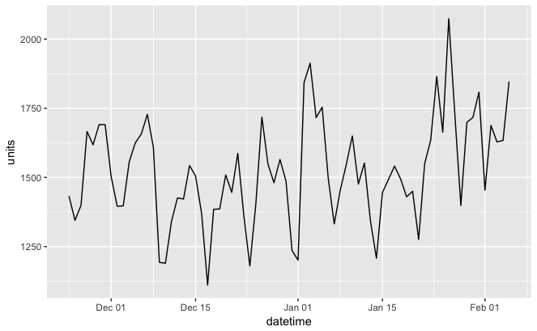

```r
# Plotting Units
qplot(datetime,units,data = metrics_2017, geom = "line")
```

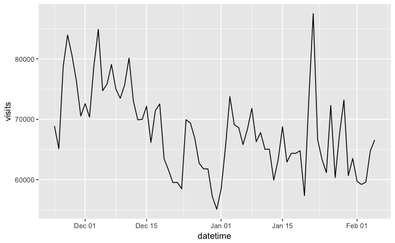

```r
#Plotting Visits
qplot(datetime,visits,data = metrics_2017, geom = "line")
```

# Market Basket Analysis (Purchase Pattern)

To understand the customer purchase pattern, we have collected transactional data including transaction ids and product ids which they have bought over period of 2-3 months.

```r
#Data preparation for Market Basket Analysis
order_products <-   QueueRanked(
  reportsuite.id = rs,
  date.from = '2016-11-24',
  date.to = '2017-02-05',
  elements = c('evar66', 'product'),
  metrics = 'units',
  top = c(10000, 50000),
  interval.seconds = 60
)
```

[output not shown]

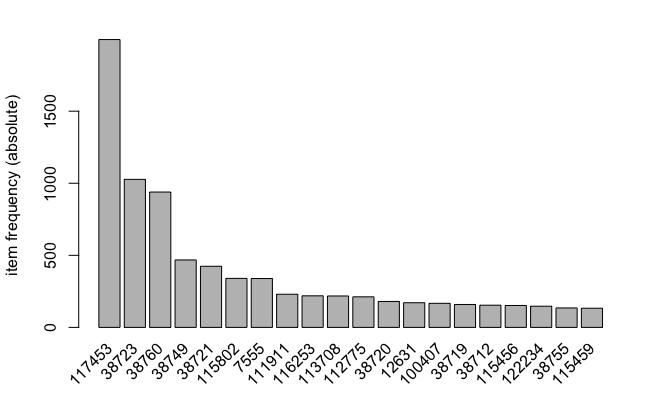

```r
txn <- order_products[,c("evar66","product")]
txn <- split(txn$product,txn$evar66)
txn <- as(txn,"transactions")
itemFrequencyPlot(txn,topN=20,type="absolute")
```

```r
basket_rules <- apriori(txn,parameter = list(support=0.001,confidence=0.1))
```

```
Apriori

Parameter specification:
 confidence minval smax arem  aval originalSupport maxtime support minlen maxlen target
        0.1    0.1    1 none FALSE            TRUE       5   0.001      1     10  rules
   ext
 FALSE

Algorithmic control:
 filter tree heap memopt load sort verbose
    0.1 TRUE TRUE  FALSE TRUE    2    TRUE

Absolute minimum support count: 10

set item appearances ...[0 item(s)] done [0.00s].
set transactions ...[2615 item(s), 10000 transaction(s)] done [0.00s].
sorting and recoding items ... [228 item(s)] done [0.00s].
creating transaction tree ... done [0.00s].
checking subsets of size 1 2 3 done [0.00s].
writing ... [84 rule(s)] done [0.00s].
creating S4 object  ... done [0.00s].
```

```r
df_basket <- as(basket_rules,"data.frame")
df_basket <- arrange(df_basket,desc(lift))
head(df_basket,20)
```

|  | rules | support | confidence | lift |
| --- | --- | --- | --- | --- |
| 1 | {87228} => {81852} | 0.0011 | 0.5500000 | 250.000000 |
| 2 | {81852} => {87228} | 0.0011 | 0.5000000 | 250.000000 |
| 3 | {115446} => {107725} | 0.0010 | 0.3448276 | 93.196645 |
| 4 | {107725} => {115446} | 0.0010 | 0.2702703 | 93.196645 |
| 5 | {38729} => {122234} | 0.0047 | 0.5053763 | 34.379343 |
| 6 | {122234} => {38729} | 0.0047 | 0.3197279 | 34.379343 |
| 7 | {38730} => {122234} | 0.0014 | 0.3783784 | 25.740026 |
| 8 | {115457} => {115465} | 0.0010 | 0.1041667 | 23.674242 |
| 9 | {115465} => {115457} | 0.0010 | 0.2272727 | 23.674242 |
| 10 | {100407} => {38731} | 0.0051 | 0.3053892 | 23.312154 |

[output cut: 10 more lines]

# Top 20 Rules

By running Market basket analysis using Apriori Alogorithm we can see top 20 purchase product ids which customers has bought together sorted by lift.

# Analysis and Recommendations

This data shows product items which are important for the customers and how company can make sure inventory of these products should always be available. In addition, while designing the marketing campaigns, company can think of bundle offers to allure new prospective customers to buy them.

# Building and Understanding Customer Segments.

it is very important to segment customers based on their similarity and dissimilarity within their browsing and purchase pattern.

```r
#Data Preparation for Clustering (Understanding Customers Segments)
user_profile <- QueueRanked(rs,
                            date.from = '2016-11-24',
                            date.to = '2017-02-05',
                            elements = c('evar48'),
                            metrics = c('units','visits','event2','pageviews','cartadditions'),
                            top = c(10000, 50),
                            interval.seconds = 120)
```

```
[1] "Requesting URL attempt #1"
[1] "Requesting URL attempt #2"
[1] "Received ranked report."
```

```r
df_user <- user_profile[,c("name","units","visits","event2","pageviews","cartadditions")]
r <- with(df_user, which(df_user$name == "::unspecified::"))
df_user <- df_user[-r,]
df_user <- df_user %>% distinct(name, .keep_all = TRUE)
rownames(df_user) <- df_user[,1]
df_user$name <- NULL
names(df_user) <- c("unitsbought", "visits","productviews","pageviews","cartadditions")
head(df_user,20)
```

|  | unitsbought | visits | productviews | pageviews | cartadditions |
| --- | --- | --- | --- | --- | --- |
| 113152 | 343 | 1003 | 1958 | 14608 | 1185 |
| 11645049 | 254 | 868 | 789 | 4315 | 61 |
| 8478735 | 236 | 1988 | 852 | 8583 | 74 |
| 2627 | 234 | 629 | 1986 | 8592 | 718 |
| 5648383 | 196 | 153 | 751 | 3111 | 384 |
| 3520245 | 159 | 101 | 430 | 2552 | 215 |
| 10171875 | 156 | 108 | 710 | 2358 | 215 |
| 984545 | 137 | 53 | 107 | 1033 | 6 |
| 8636459 | 134 | 105 | 259 | 1921 | 127 |
| 2698238 | 110 | 53 | 259 | 742 | 116 |

[output cut: 10 more lines]

# Optimal Number of Clusters

To start with, we need to see how many clusters/segments can be possible within available data sets. We have used Elbow method to find optimal number of segments. Based on the Elbow’s plot, 2 or 4 are the best number of clusters and we have chosen 3 as average optimal number of segments.

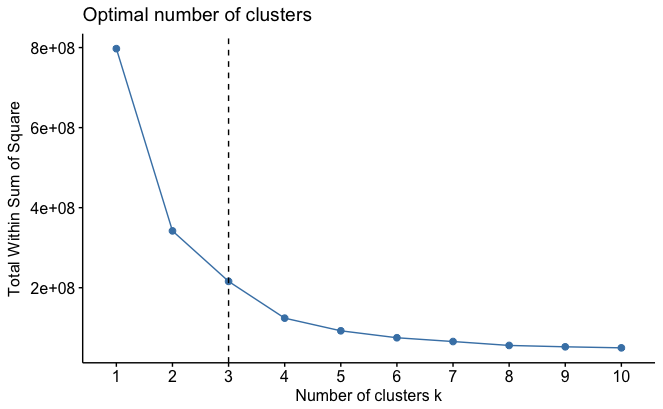

```r
#Number of clusters using Elbow method
fviz_nbclust(df_user, kmeans, method = "wss") +
  geom_vline(xintercept = 3, linetype = 2)
```

# K-means algorithm

After running k-means clustering method, we have seen maximum number of data points are part of cluster 2 and lowest number of data points comes under cluster 1 and 3. But based on their properties, all of them has their own significance in solving business problems.

```r
#K-Means Clustering
k.means.fit <- kmeans(df_user,3)
attributes(k.means.fit)
```

```
$names
[1] "cluster"      "centers"      "totss"        "withinss"     "tot.withinss"
[6] "betweenss"    "size"         "iter"         "ifault"

$class
[1] "kmeans"
```

```r
k.means.fit$centers
```

```
  unitsbought      visits productviews  pageviews cartadditions
1  207.500000 1003.750000    2049.5000 10470.7500    793.250000
2    4.136088    5.971675      20.4482    75.3071      4.662549
3    8.804636   31.903974     184.1573   520.4917     35.711921
```

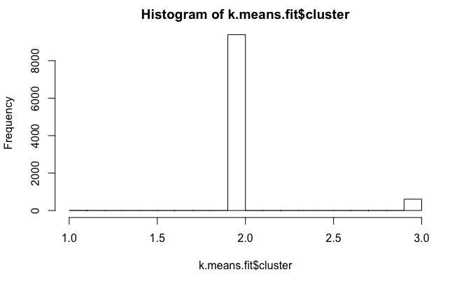

```r
hist(k.means.fit$cluster)
```

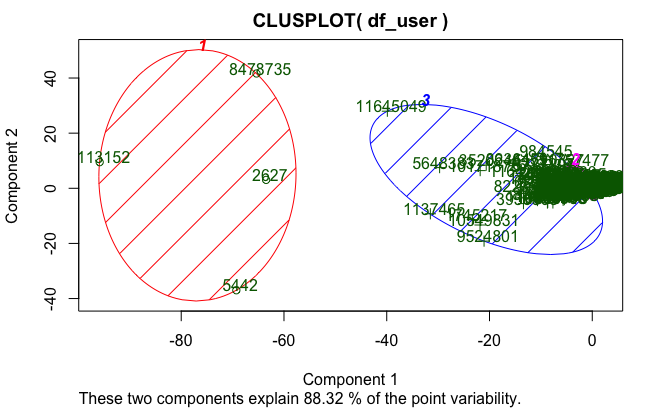

```r
clusplot(df_user, k.means.fit$cluster, color=TRUE, shade=TRUE,
         labels=2, lines=0)
```

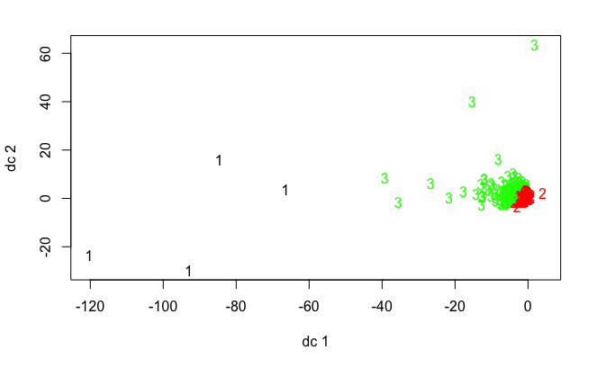

```r
# Centroid Plot against 1st 2 discriminant functions
plotcluster(df_user, k.means.fit$cluster)
```

# Analysis and Recommendations

Segment 1/Cluster 1 consists of very few customer ids with kind of abnormal browsing and purchase pattern. They look like outliers who bought many product items and it is very much required for the company to verify their identity. It is quite possible they are part of technical team who are doing live testing on the platform, or some scammers who buying excess of product items and selling them in black market.

Segment3/Cluster 3 consist of subset of customer ids who are very active on website but they are not purchasing much. There is very high cart abandonment rate here and company can do further analysis to find the reason of it. We can call this customer segment as researcher and with right marketing campaign, we can make them to buy products.

Segment2/Cluster2 consists of large customer ids who has idle browsing and purchase pattern. They are visiting right number of pages and product views, adding right number of products in their cart and purchasing them with minimal cart abandonment rate. Out of average 5 visits, they are seeing 20 products and ending up buying 4 of them.

# Hierarchical Clustering

In addition, we have done hierarchical clustering where we have not mentioned number of segments beforehand. Depending on us, we can select as many clusters based on height of the dendrogram. We can cut the tree into any number of clusters.

```r
# Tree Clustering
d <- daisy(df_user,metric = "gower")
summary(d)
```

```
49985001 dissimilarities, summarized :
     Min.   1st Qu.    Median      Mean   3rd Qu.      Max.
0.0000000 0.0026223 0.0049760 0.0083743 0.0090911 0.8135400
Metric :  mixed ;  Types = I, I, I, I, I
Number of objects : 9999
```

```r
d_mat <- as.matrix(d)
# Most Similar Pair
df_user[
  which(d_mat == min(d_mat[d_mat != min(d_mat)]),
        arr.ind = TRUE)[1, ], ]
```

|  | unitsbought | visits | productviews | pageviews | cartadditions |
| --- | --- | --- | --- | --- | --- |
| 11655433 | 6 | 1 | 0 | 63 | 0 |
| 7068467 | 6 | 1 | 0 | 64 | 0 |

```r
fit <- hclust(d,method = "ward")
```

```
The "ward" method has been renamed to "ward.D"; note new "ward.D2"
```

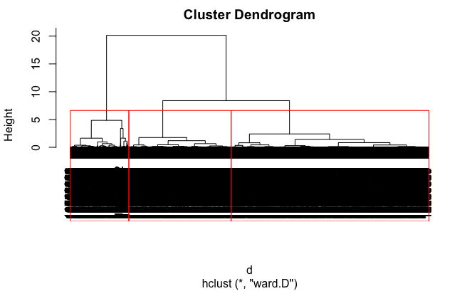

```r
plot(fit)
groups <- cutree(fit,k=3)
rect.hclust(fit,k=3,border = "red")
```

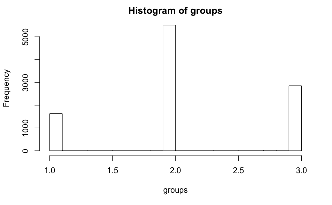

```r
hist(groups)
```

# Analysis and Recommendation

We found interesting pair of customers who share similar pattern where they had only 1 visit and possibly, they had products in their basket from their previous visits and purchased 6 units of products directly in their single visit.

# Correlation and Covariance

It is important to find the correlation between all given data points, and based on correlation analysis output, there is no correlation between units bought with any of the data points such as visits, product views, page views and cart additions.

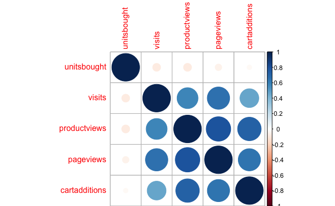

```r
#Regression to find out variables which are dependent on customers who bought the products
#Understanding Correlation and Covariance
cor <- cor(df_user, use="complete.obs", method="kendall")
cov <- cov(df_user, use="complete.obs")
corrplot(cor, method="circle")
```

# Feature Selection and Regression Model

Since, we are going to run regression model, it is important to select right independent variable and hence here we run Stepwise Model path algorithm to find optimal Model based on given initial model. There is no change in Final Model and it is better to include all independent variables for regression modeling.

```r
#Feature Selection
library(MASS)
multi_fit <- lm(df_user$unitsbought~ df_user$visits + df_user$productviews + df_user$pageviews + df_user$cartadditions)
step <- stepAIC(multi_fit, direction="both")
```

```
Start:  AIC=31595.38
df_user$unitsbought ~ df_user$visits + df_user$productviews +
    df_user$pageviews + df_user$cartadditions

                        Df Sum of Sq    RSS   AIC
<none>                               235412 31595
- df_user$cartadditions  1       323 235735 31607
- df_user$visits         1       457 235870 31613
- df_user$pageviews      1     38344 273757 33102
- df_user$productviews   1     53130 288543 33628
```

```r
step$anova
```

```
Stepwise Model Path
Analysis of Deviance Table

Initial Model:
df_user$unitsbought ~ df_user$visits + df_user$productviews +
    df_user$pageviews + df_user$cartadditions

Final Model:
df_user$unitsbought ~ df_user$visits + df_user$productviews +
    df_user$pageviews + df_user$cartadditions


  Step Df Deviance Resid. Df Resid. Dev      AIC
1                       9994   235412.4 31595.38
```

# Outlier Analysis

Since, we know about outlier data points, Outlier test gave us data points with outlier values.

```r
# Assessing Outliers
outlierTest(multi_fit) # Bonferonni p-value for most extreme obs
```

```
      rstudent unadjusted p-value Bonferonni p
2     32.73772        2.1538e-223  2.1536e-219
5     30.84586        1.1930e-199  1.1928e-195
7     25.81342        2.6975e-142  2.6973e-138
94   -25.01246        5.5849e-134  5.5843e-130
8     22.34930        5.2834e-108  5.2829e-104
6     21.18957         1.6316e-97   1.6315e-93
10    21.08956         1.2401e-96   1.2399e-92
12    20.26559         1.6055e-89   1.6054e-85
9069  17.61855         1.9121e-68   1.9119e-64
9     17.52939         8.7860e-68   8.7851e-64
```

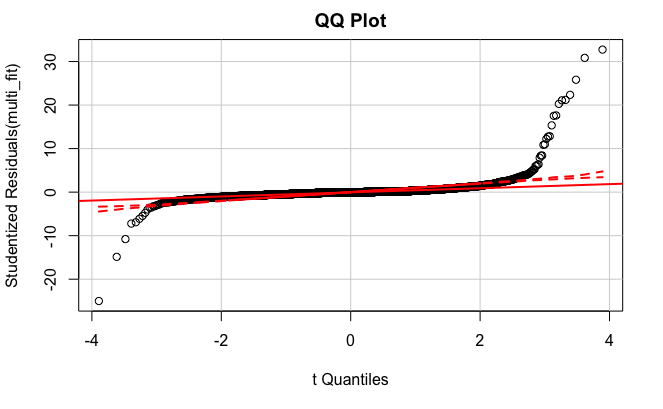

```r
qqPlot(multi_fit, main="QQ Plot") #qq plot for studentized resid
```

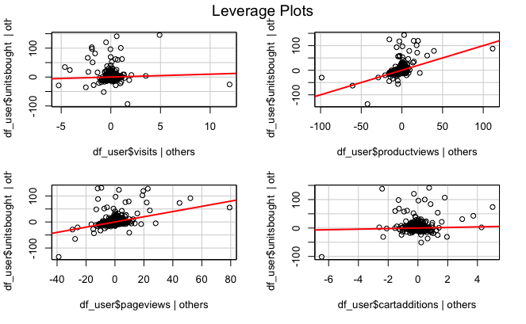

```r
leveragePlots(multi_fit) # leverage plots
```

# Understanding Regression Model and Analysis

Based on P values (P<0.05), every predictor in the model is significant. Hence our dependent variable, depends on all four predictors. Based on regression coefficient, with increase in 1 unit of visits and page views, units bought will increase by 0.017 and 0.033 units. In addition, with increase in 1 unit of product views and cart addition, units bought will decrease by -0.06 and -0.02 units respectively. This is because, we have seen in analysis report - if user is seeing more and more product views that does not meet he will buy the product. There is a higher chance that he is just a researcher and part of Cluster/Segment 3.

Based on Residual vs Fitted graph, we have can see that there is no linear relationship between dependent and independent variables. Since we are trying to model user behavior, it is not possible that they will have linear relationship.

Graph 3 shows our residuals has not equally spread, it is again due to few major outliers in the model.

Graph 4 proves our hypothesis towards outliers, outliers are influential in linear regression analysis.

```r
summary(multi_fit)
```

```
Call:
lm(formula = df_user$unitsbought ~ df_user$visits + df_user$productviews +
    df_user$pageviews + df_user$cartadditions)

Residuals:
    Min      1Q  Median      3Q     Max
-95.029  -1.376  -0.187   0.810 140.669

Coefficients:
                        Estimate Std. Error t value Pr(>|t|)
(Intercept)            2.8675756  0.0528549  54.254  < 2e-16 ***
df_user$visits         0.0179108  0.0040646   4.407 1.06e-05 ***
df_user$productviews  -0.0630949  0.0013285 -47.493  < 2e-16 ***
df_user$pageviews      0.0338286  0.0008385  40.346  < 2e-16 ***
df_user$cartadditions -0.0208476  0.0056320  -3.702 0.000215 ***
---
Signif. codes:  0 ‘***’ 0.001 ‘**’ 0.01 ‘*’ 0.05 ‘.’ 0.1 ‘ ’ 1

Residual standard error: 4.853 on 9994 degrees of freedom
Multiple R-squared:  0.5754,    Adjusted R-squared:  0.5752
F-statistic:  3386 on 4 and 9994 DF,  p-value: < 2.2e-16
```

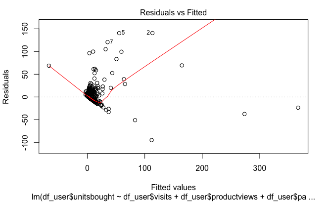

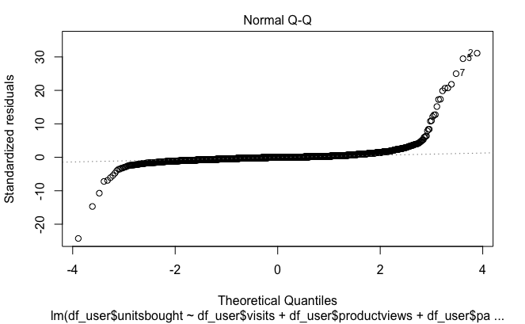

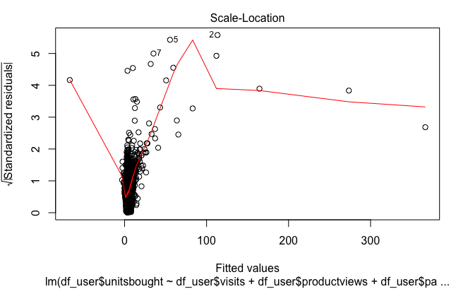

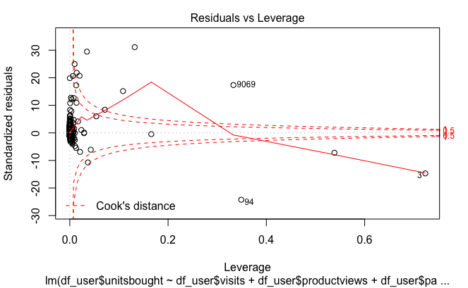

```r
plot(multi_fit)
```

# Recommendations

We have tried to build predictive regression model on user behavior data and it is really tough to show user psychology behind shopping pattern using mathematical equation. Our analysis has shown lot of outliers which are part of cluster 1 and cluster 3 but has their own significance in terms of understanding few higher spenders or researches. It is better to build model on cluster 2 which is stable customers and their behavior is an idle behavior, and it is quite possible it will come up with more better results. But we can’t ignore our outliers because we are quite interested in understanding them as well because they can be threat or an opportunity for the business.